# Airline Loyalty Analytics in R

created by Péter Szilvási

2024.02.02.

## Introduction of the Dataset

`Airline Loyalty Program` is a relational dataset about a fictitious Canadian airline’s loyalty program, including data about members’ activity and their information. It includes 2 tables, 28 fields, and 412,230 observations.

The source is [Maven Analytics](https://mavenanalytics.io/data-playground?search=airline%20loyalty%20program).

## Business Questions

- Show KPIs of the performance of the Program.
  - How many total points were collected, how many were redeemed?
  - How many dollars were saved by our customers? Total and on average.
- Show a trendline in the Program from 2017 and 2018
  - How many total flights were in each month?
  - Show seasonalities if there are any.
- How is Customer Lifetime Value (CLV)?
  - What is the association between city population and CLV?
  - Show city statistics
  - Show demographics of CLV.
- Do we have trendlines in signup/cancellation dates?

## Setting up the environment

```r
# importing libraries
library(data.table)
library(ggplot2) # for data visualizations
library(maps) # there is a canada table built in
library(scales) # helps transform axis scales
library(gridExtra) # can put together more plots in ggplot
library(RColorBrewer) # use for color brewing from colorbrewer2.org
```

```r
# import loyalty table from GitHub
loyalty <- data.table(read.csv(
  'https://raw.githubusercontent.com/szilvasipeter2000/R/main/loyalty_history.csv'))

# import flight activity table from GitHub
activity <- data.table(read.csv(
  'https://raw.githubusercontent.com/szilvasipeter2000/R/main/flight_activity.csv'))
```

## Performance of the Program

We can look at the total points collected, total points redeemed, dollars saved, and other program performance indicators.

```r
# aggregated table
loyalty_points <- activity[, .(total_points = sum(Points.Accumulated),
                                  total_redeemed = sum(Points.Redeemed),
                                  dollars_saved = sum(Dollar.Cost.Points.Redeemed),
                                  points_per_dollar = sum(Points.Redeemed)/sum(Dollar.Cost.Points.Redeemed),
                                  points_left = pmax(0, sum(Points.Accumulated) - sum(Points.Redeemed))),by= Loyalty.Number]

# adding missed savings, shows how much customers could have saved with the loyalty program
loyalty_points$missed_savings <- loyalty_points$points_left/loyalty_points$points_per_dollar

loyalty_stats <- data.table(loyalty_points)[,lapply(.SD,function(x) sum(x)),
                    .SDcols = c('total_points','total_redeemed','dollars_saved','points_left')]

loyalty_stats$average_saved_per_person <- loyalty_stats$dollars_saved/loyalty[,.N]
loyalty_stats$perc_of_points_used <- loyalty_stats$total_redeemed/loyalty_stats$total_points
loyalty_stats$dollars_to_save <- loyalty_stats$points_left/mean(loyalty_points$points_per_dollar,na.rm = TRUE)
```

```
##    total_points total_redeemed dollars_saved points_left
## 1:     50172736       12451388       1007774    37780603
##    average_saved_per_person perc_of_points_used dollars_to_save
## 1:                 60.21234           0.2481704         3058952
```

Over 50 million points were collected, out of which only 12 million was redeemed. This means that only 24.8% of total points were used, which overall led to 1 million dollars saved by our members, 60$ on average per person.

We can also plot how loyalty members utilized the benefits of the program. How much dollars they saved compared to how much they could have saved

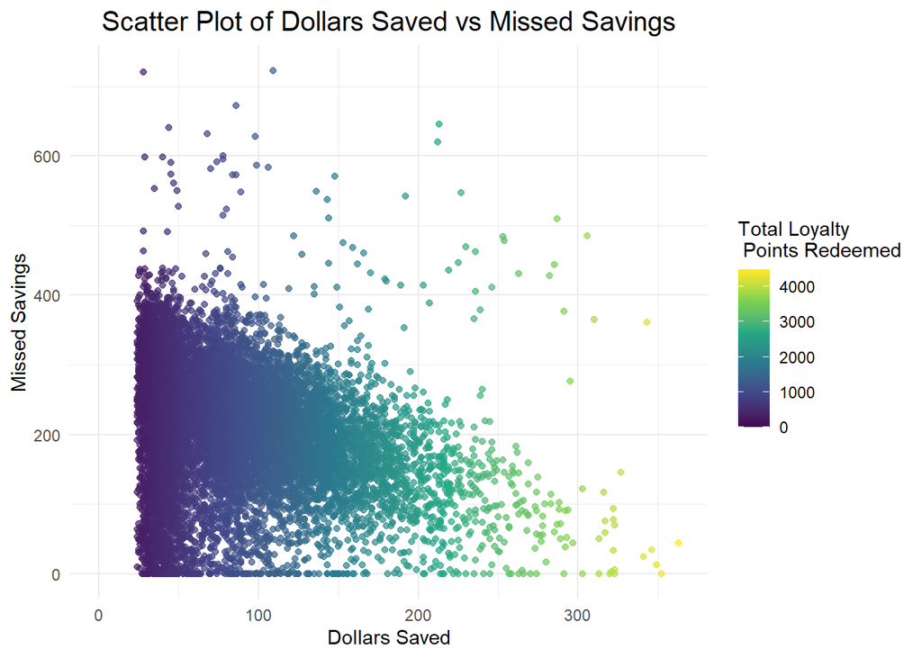

```r
ggplot(loyalty_points, aes(x = dollars_saved, y = missed_savings, color = total_redeemed)) +
  geom_point(size = 1.5, alpha = 0.7) +
  labs(title = "Scatter Plot of Dollars Saved vs Missed Savings",
       x = "Dollars Saved",
       y = "Missed Savings",
       color = "Total Redeemed") +
  theme_minimal() +
  scale_color_continuous(name = "Total Loyalty \n Points Redeemed",type = "viridis")+
  theme(plot.title = element_text(hjust = 0.5, size = 15))
```

## Trendline of our Program

Let’s look at how our program performed in its lifetime, 2017 and 2018. Compare customer dollar savings with the number of flights our company had in the period.

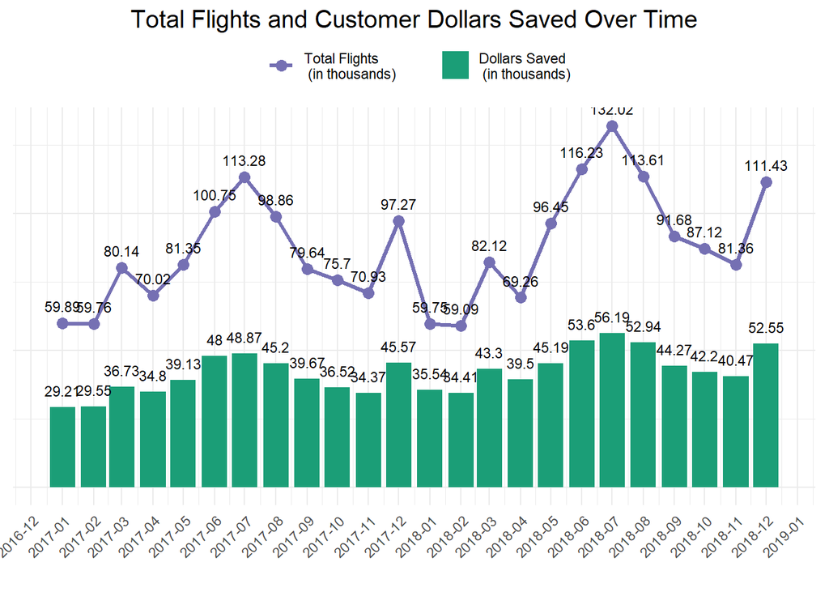

```r
ggplot(flights_by_date) +
  geom_line(aes(x = period, y = total_flights / 1000, color = "Total Flights \n (in thousands)"), stat = 'identity', linewidth = 1.2) +
  geom_point(aes(x = period, y = total_flights / 1000, color = "Total Flights \n (in thousands)"), size = 3) +
  geom_col(aes(x = period, y = dollars_saved, fill = "Dollars Saved \n (in thousands)"), position = 'identity') +
  geom_text(aes(x = period, y = dollars_saved, label = round(dollars_saved, 2)),
            position = position_dodge(width = 0.9), vjust = -1, size = 3, color = "black") +
  geom_text(aes(x = period, y = total_flights / 1000 + 0.2, label = round(total_flights / 1000, 2)),
            position = position_dodge(width = 0.9), vjust = -1, size = 3, color = "black") +
  scale_y_continuous(name = "Total Flights (in thousands)", sec.axis = sec_axis(trans = ~ ., name = "Points Redeemed (scaled)")) +
  labs(title = "Total Flights and Customer Dollars Saved Over Time", x = '') +
  scale_color_manual(name = "", values = c("Total Flights \n (in thousands)" = "#7570b3")) +
  scale_fill_manual(name = "", values = c("Dollars Saved \n (in thousands)" = "#1b9e77")) +
  theme_minimal() +
  theme(legend.position = "top", legend.box = "horizontal", legend.title.align = 0.5) +
  scale_x_date(date_labels = "%Y-%m", date_breaks = "1 month") +
  theme(axis.text.x = element_text(angle = 45, hjust = 1)) +
  theme(plot.title = element_text(hjust = 0.5, size = 15)) +
  theme(axis.title.y = element_blank(), axis.text.y = element_blank(), axis.ticks.y = element_blank())
```

It is visible that in the summer, there are peaks in the number of flights, which is followed by an increase in the dollars saved. It is also clear that the trend of savings follows the trend in the number of flights. Even so, the increase in the number of flights is also clear. Year by year, the company is having more and more customers.

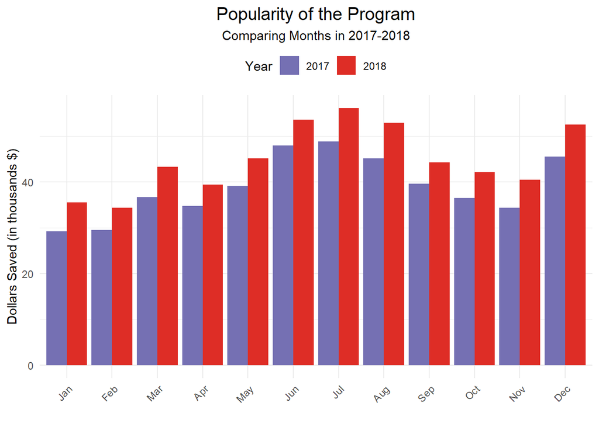

```r
# Plot the increase in popularity of the program
ggplot(flights_by_date, aes(factor(Month, labels = month_names), dollars_saved, fill = as.factor(Year))) +
  geom_col(position = 'dodge') +
  labs(title = "Popularity of the Program",subtitle = "Comparing Months in 2017-2018", y = "Dollars Saved (in thousands $)", x = "", fill = "Year") +
  theme_minimal() +
  scale_fill_manual(values = c("#7570b3","#de2d26"))+
  theme(plot.title = element_text(hjust = 0.5, size = 15),
        plot.subtitle = element_text(hjust = 0.5),
        axis.text.x = element_text(angle = 45, hjust = 1),
        legend.position = "top", legend.box = "horizontal", legend.title.align = 0.5)
```

The increase in the popularity of our loyalty program is clearly visible. If we compare each month of 2018 with its corresponding value in 2017, there is not one that hasn’t increased.

## Customer Lifetime Value

Let’s look at some geographical representation of our members’ Customer Lifetime Value (CLV), which shows the total invoice value for all flights ever booked by the member.

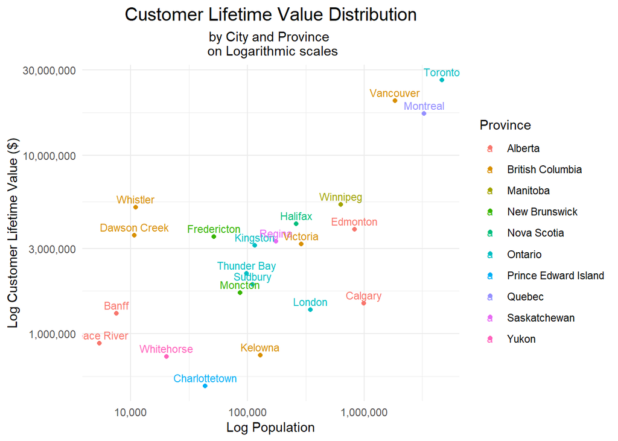

```r
ggplot(clv_population, aes(pop, V1, color = Province)) +
  geom_point() +
  geom_text(aes(label = City), vjust = -0.5, hjust = 0.5, size = 3) +
  labs(title = 'Customer Lifetime Value Distribution', subtitle = "by City and Province \n on Logarithmic scales", x = 'Log Population', y = 'Log Customer Lifetime Value ($)') +
  scale_y_log10(labels = scales::comma) +  # log-scale with thousand separator
  scale_x_log10(labels = scales::comma) +  # log-scale with thousand separator
  theme_minimal() +
  theme(plot.title = element_text(hjust = 0.5, size = 15),
        plot.subtitle = element_text(hjust = 0.5))
```

Here I use logarithmic scales as otherwise other than the 3 big cities, Toronto, Vancouver, and Montreal, we couldn’t see anything about the other cities. Obviously, these 3 cities bring by far the most CLV to the company, but it is still worth looking into the smaller cities. One interesting case is Calgary, which has pretty high Population, but still fails to produce a corresponding high amount of CLV. This city is also located quite far from all other big cities so one might think they fly a lot. Might be worth looking into which competition they use to fly with.

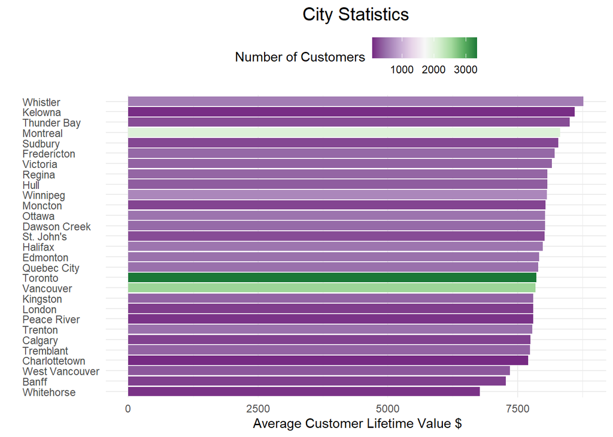

```r
ggplot(loyalty_summary, aes(x = CLV, reorder(City,CLV), fill = ncustomer)) +
  geom_col() +
  scale_fill_gradientn(colours = brewer.pal(9, "PRGn")) +
  labs(title = "City Statistics",
       x = " Average Customer Lifetime Value $",
       y = "",
       fill = "Number of Customers") +
  theme_minimal() +
  theme(axis.text.y = element_text(hjust = 0),
        legend.position = "top",
        plot.title = element_text(hjust = 0.5, size = 15))
```

While Toronto and Vancouver bring in the most Customers, it is visible that the average CLV is by far not from that group. Montreal on the other hand has a relatively high average CLV and also a good amount of Customers.

## Let’s look at some demographics of our Customers.

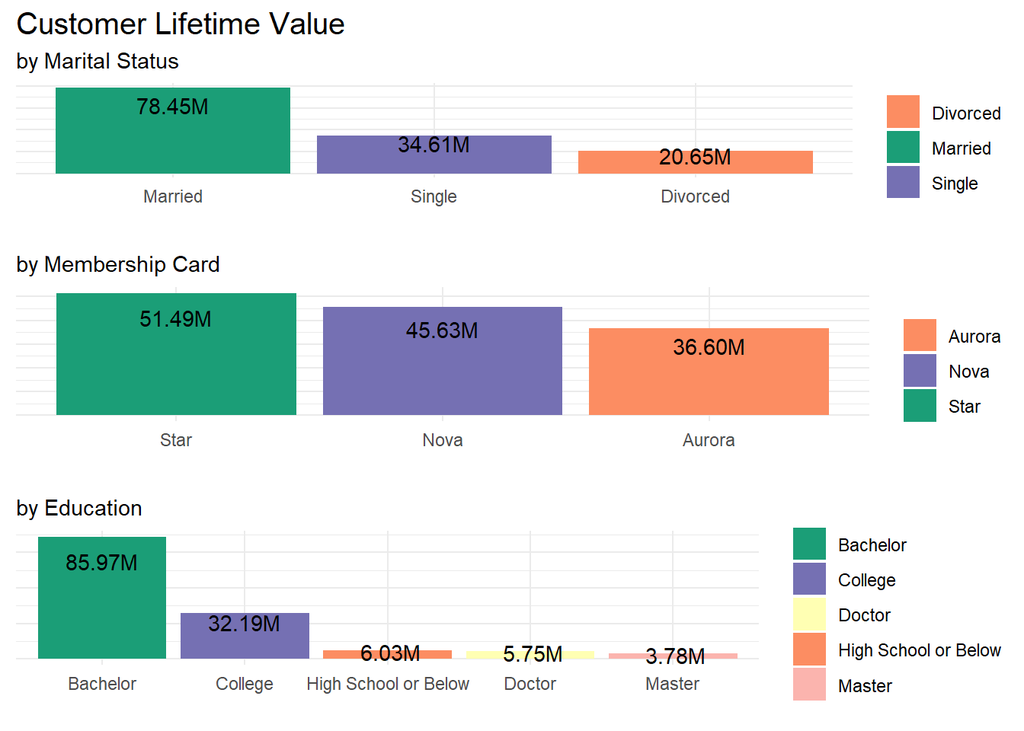

```r
# Create the bar graph for each facet
p1 <- ggplot(marital_agg_data, aes(reorder(Marital.Status,-CLV), y = CLV, fill = Marital.Status,label=label)) +
  geom_bar(stat = "identity") +
  geom_text(position = position_stack(vjust = 0.8)) +
  labs(title = "Customer Lifetime Value",
       subtitle = "by Marital Status",
       x = "",
       fill = "") +
  theme_minimal()+
  scale_fill_manual(values = c("#fc8d62", "#1b9e77", "#7570b3"))+
  theme(plot.title = element_text(size = 15),
        axis.title.y = element_blank(),  # remove y-axis title
        axis.text.y = element_blank(),   # remove y-axis tick labels
        axis.ticks.y = element_blank())  # remove y-axis ticks

p2 <- ggplot(card_agg_data, aes(reorder(Loyalty.Card,-CLV), y = CLV, fill = Loyalty.Card,label=label)) +
  geom_bar(stat = "identity") +
  geom_text(position = position_stack(vjust = 0.8)) +
  labs(subtitle = "by Membership Card",
       x = "",
       fill = "") +
  theme_minimal()+
  scale_fill_manual(values = c("#fc8d62","#7570b3", "#1b9e77"))+
  theme(axis.title.y = element_blank(),
        axis.text.y = element_blank(),
        axis.ticks.y = element_blank())

p3 <- ggplot(ed_agg_data, aes(reorder(Education,-CLV), y = CLV, fill = Education,label=label)) +
  geom_bar(stat = "identity") +
  geom_text(position = position_stack(vjust = 0.8)) +
  labs(subtitle = "by Education",
       x = "",
       fill = "") +
  theme_minimal()+
  scale_fill_manual(values = c("#1b9e77","#7570b3","#ffffb3","#fc8d62","#fbb4ae"))+
  theme(axis.title.y = element_blank(),
        axis.text.y = element_blank(),
        axis.ticks.y = element_blank())

# Arrange the plots side by side
grid.arrange(p1, p2, p3, nrow = 3)
```

Here we can see aggregated Customer Lifetime Values for 3 categories. Married people brought by far the most value. Between Star and Nova Membership, there is a small difference. Both have quite high values. Aurora is also performing quite well. As for Education, individuals with Bachelor’s degrees bring by far the most value to the company.

## New signups and Cancellations

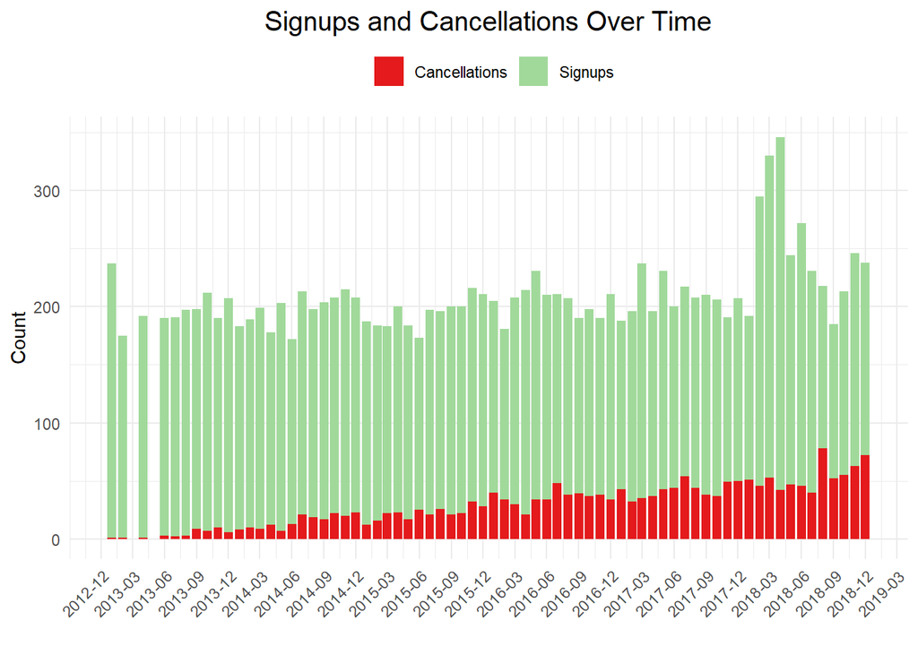

```r
ggplot(singups_cancellations, aes(x = period)) +
  geom_bar(aes(y = nsignups, fill = "Signups"), stat = "identity") +
  geom_bar(aes(y = ncancellations, fill = "Cancellations"), stat = "identity") +
  labs(title = "Signups and Cancellations Over Time",
       x = "",
       y = "Count",
       fill = "Event Type") +
  scale_fill_manual(name = "", values = c("Signups" = "#a1d99b", "Cancellations" = "#e41a1c")) +
  theme_minimal() +
  scale_x_date(date_labels = "%Y-%m", date_breaks = "3 month") +
  theme(axis.text.x = element_text(angle = 45, hjust = 1))+
  theme(plot.title = element_text(hjust = 0.5, size = 15))+
  theme(legend.position = "top", legend.box = "horizontal", legend.title.align = 0.5)
```

There might be an increase in the popularity of utilizing the benefits of the program, but the number of new signups, except for 1 peak in 2018, clearly has been constant for some time. However, the number of people who cancel their membership is increasing year by year.